# Binary Classification Deep Learning Model for Truck APS Failure Using TensorFlow Take 4

### August 3, 2020

Template Credit: Adapted from a template made available by Dr. Jason Brownlee of Machine Learning Mastery. [https://machinelearningmastery.com/]

SUMMARY: The purpose of this project is to construct a predictive model using various machine learning algorithms and to document the end-to-end steps using a template. The Truck APS Failure dataset is a binary classification situation where we are trying to predict one of the two possible outcomes.

INTRODUCTION: The dataset consists of data collected from heavy Scania trucks in everyday usage. The system in focus is the Air Pressure system (APS), which generates pressurized air that supports functions such as braking and gear changes. The dataset’s positive class consists of component failures for a specific component of the APS system. The negative class consists of trucks with failures for components not related to the APS. The training set contains 60000 examples in total, in which 59000 belong to the negative class and 1000 positive class. The test set contains 16000 examples.

The challenge is to minimize the total cost of a prediction model the sum of “Cost_1” multiplied by the number of Instances with type 1 failure and "Cost_2" with the number of instances with type 2 failure. The “Cost_1” variable refers to the cost resulted from a redundant check by a mechanic at the workshop. Meanwhile, the “Cost_2” variable refers to the cost of not catching a faulty truck. The cost of Type I error (cost_1) is 10, while the cost of the Type II error (cost_2) is 500.

In the previous Scikit-Learn iterations, we constructed and tuned machine learning models for this dataset using the Scikit-Learn and the XGboost libraries. We also observed the best accuracy result that we could obtain using the tuned models with the training, validation, and test datasets.

In iteration Take1, we constructed and tuned machine learning models for this dataset using TensorFlow with three layers. We also observed the best result that we could obtain using the tuned models with the validation and test datasets.

In this Take3 iteration, we constructed and tuned machine learning models for this dataset using TensorFlow with four layers. At the same time, we leveraged the SMOTE technique to augment the dataset for training purposes. Furthermore, we also observed the best result that we could obtain using the tuned models with the validation and test datasets.

In this Take4 iteration, we will construct and tune machine learning models for this dataset using TensorFlow with five layers. At the same time, we will leverage the SMOTE technique to augment the dataset for training purposes. Furthermore, we will observe the best result that we can obtain using the tuned models with the validation and test datasets.

ANALYSIS: From the previous Scikit-Learn iterations, the optimized XGBoost model processed the testing dataset with a recall metric of 98.66% with a low Type II error rate.

From this Take1 iteration, the performance of the three-layer TensorFlow model achieved a recall score of 77.20% with the training dataset. After a series of tuning trials, the TensorFlow model processed the validation dataset with a recall score of 75.20%, which was consistent with the prediction from the training result. When configured with the optimized parameters, the TensorFlow model processed the test dataset with a recall score of 55.46% with a high Type II error rate.

From iteration Take2, the performance of the three-layer TensorFlow model achieved a recall score of 87.60% with the training dataset. After a series of tuning trials, the TensorFlow model processed the validation dataset with a recall score of 96.40%, which was much better than the prediction from the training result. When configured with the optimized parameters, the TensorFlow model processed the test dataset with a recall score of 85.06% with a lower Type II error rate than the previous iteration.

From iteration Take3, the performance of the four-layer TensorFlow model achieved a recall score of 83.60% with the training dataset. After a series of tuning trials, the TensorFlow model processed the validation dataset with a recall score of 93.20%, which was much better than the prediction from the training result. When configured with the optimized parameters, the TensorFlow model processed the test dataset with a recall score of 95.73% with a lower Type II error rate than the previous iteration.

From this Take4 iteration, the performance of the five-layer TensorFlow model achieved a recall score of 86.80% with the training dataset. After a series of tuning trials, the TensorFlow model processed the validation dataset with a recall score of 96.00%, which was much better than the prediction from the training result. When configured with the optimized parameters, the TensorFlow model processed the test dataset with a recall score of 98.66% with a lower Type II error rate but abysmal accuracy.

CONCLUSION: For this dataset, the model built using TensorFlow with four layers seems to yield the best result with a little help from applying SMOTE to balance the dataset. We should consider using TensorFlow and SMOTE to model this dataset further.

Dataset Used: APS Failure at Scania Trucks Data Set

Dataset ML Model: Binary classification with numerical attributes

Dataset Reference: https://archive.ics.uci.edu/ml/datasets/APS+Failure+at+Scania+Trucks

One potential source of performance benchmark: https://archive.ics.uci.edu/ml/datasets/APS+Failure+at+Scania+Trucks

A deep-learning modeling project generally can be broken down into five major tasks:

1. Prepare Environment
2. Load and Prepare Data
3. Define and Train Model
4. Evaluate and Optimize Model
5. Finalize Model and Make Predictions

# Task 1. Prepare Environment

```python
# Install the packages to support accessing environment variable and SQL databases
!pip install python-dotenv PyMySQL
```

```
     |████████████████████████████████| 51kB 5.5MB/s
```

```python
# Retrieve GPU configuration information from Colab
gpu_info = !nvidia-smi
gpu_info = '\n'.join(gpu_info)
if gpu_info.find('failed') >= 0:
    print('Select the Runtime → "Change runtime type" menu to enable a GPU accelerator, ')
    print('and then re-execute this cell.')
else:
    print(gpu_info)
```

```
Mon Jul 27 13:59:10 2020
+-----------------------------------------------------------------------------+
| NVIDIA-SMI 450.51.05    Driver Version: 418.67       CUDA Version: 10.1     |
|-------------------------------+----------------------+----------------------+
| GPU  Name        Persistence-M| Bus-Id        Disp.A | Volatile Uncorr. ECC |
| Fan  Temp  Perf  Pwr:Usage/Cap|         Memory-Usage | GPU-Util  Compute M. |
|                               |                      |               MIG M. |
|===============================+======================+======================|
|   0  Tesla P100-PCIE...  Off  | 00000000:00:04.0 Off |                    0 |
| N/A   34C    P0    25W / 250W |      0MiB / 16280MiB |      0%      Default |
|                               |                      |                 ERR! |
+-------------------------------+----------------------+----------------------+

+-----------------------------------------------------------------------------+
| Processes:                                                                  |
|  GPU   GI   CI        PID   Type   Process name                  GPU Memory |
|        ID   ID                                                   Usage      |
|=============================================================================|
|  No running processes found                                                 |
+-----------------------------------------------------------------------------+
```

```python
# Retrieve memory configuration information from Colab
from psutil import virtual_memory
ram_gb = virtual_memory().total / 1e9
print('Your runtime has {:.1f} gigabytes of available RAM\n'.format(ram_gb))

if ram_gb < 20:
    print('To enable a high-RAM runtime, select the Runtime → "Change runtime type"')
    print('menu, and then select High-RAM in the Runtime shape dropdown. Then, ')
    print('re-execute this cell.')
else:
    print('You are using a high-RAM runtime!')
```

```
Your runtime has 13.7 gigabytes of available RAM

To enable a high-RAM runtime, select the Runtime → "Change runtime type"
menu, and then select High-RAM in the Runtime shape dropdown. Then,
re-execute this cell.
```

```python
# Direct Colab to use TensorFlow v2
%tensorflow_version 2.x
```

```python
# Retrieve CPU information from the system
ncpu = !nproc
print("The number of available CPUs is:", ncpu[0])
```

```
The number of available CPUs is: 2
```

```python
# Set the random seed number for reproducible results
seedNum = 888
```

```python
# Load libraries and packages
import random
random.seed(seedNum)
import numpy as np
np.random.seed(seedNum)
import tensorflow as tf
tf.random.set_seed(seedNum)
from tensorflow import keras
import pandas as pd
import matplotlib.pyplot as plt
import seaborn as sns
import os
import sys
import math
import boto3
from datetime import datetime
from dotenv import load_dotenv
from sklearn import preprocessing
from sklearn.model_selection import train_test_split
from sklearn.metrics import confusion_matrix
from imblearn.pipeline import Pipeline
from imblearn.over_sampling import SMOTE
from imblearn.under_sampling import RandomUnderSampler
```

```python
# Begin the timer for the script processing
startTimeScript = datetime.now()

# Check the number of GPUs accessible through TensorFlow
print("Num GPUs Available: ", len(tf.config.experimental.list_physical_devices('GPU')))

# Set up the number of CPU cores available for multi-thread processing
n_jobs = 1

# Set up the flag to stop sending progress emails (setting to True will send status emails!)
notifyStatus = False

# Set up the parent directory location for loading the dotenv files
useGDrive = False
if useGDrive:
    # Mount Google Drive locally for storing files
    from google.colab import drive
    drive.mount('/content/gdrive')
    gdrivePrefix = '/content/gdrive/My Drive/Colab_Downloads/'
    env_path = '/content/gdrive/My Drive/Colab Notebooks/'
    dotenv_path = env_path + "python_script.env"
    load_dotenv(dotenv_path=dotenv_path)

# Set up the dotenv file for retrieving environment variables
useLocalPC = False
if useLocalPC:
    env_path = "/Users/david/PycharmProjects/"
    dotenv_path = env_path + "python_script.env"
    load_dotenv(dotenv_path=dotenv_path)

# Configure the plotting style
plt.style.use('seaborn')

# Set Pandas options
pd.set_option("display.max_rows", None)
pd.set_option("display.max_columns", None)
pd.set_option("display.width", 140)

# Set the number of folds for cross validation
n_folds = 5

# Set the percentage sizes for splitting the dataset
test_set_size = 0.2
val_set_size = 0.25

# Set various default Keras modeling parameters
default_loss = keras.losses.BinaryCrossentropy()
# default_metrics = ['accuracy']
default_metrics = [
    keras.metrics.TruePositives(name='tp'),
    keras.metrics.FalsePositives(name='fp'),
    keras.metrics.TrueNegatives(name='tn'),
    keras.metrics.FalseNegatives(name='fn'),
    keras.metrics.BinaryAccuracy(name='accuracy'),
    keras.metrics.Precision(name='precision'),
    keras.metrics.Recall(name='recall'),
    keras.metrics.AUC(name='auc'),
]
default_optimizer = keras.optimizers.Adam(learning_rate=0.001)
default_kernel_init = keras.initializers.he_uniform(seed=seedNum)
default_epoch = 20
default_batch = 64

# Define the labels to use for analyzing models
train_metric = "recall"
validation_metric = "val_recall"

# Business case metrics
cost_1 = 10
cost_2 = 500
```

```
Num GPUs Available:  1
```

```python
# Set up the email notification function
def status_notify(msg_text):
    access_key = os.environ.get('SNS_ACCESS_KEY')
    secret_key = os.environ.get('SNS_SECRET_KEY')
    aws_region = os.environ.get('SNS_AWS_REGION')
    topic_arn = os.environ.get('SNS_TOPIC_ARN')
    if (access_key is None) or (secret_key is None) or (aws_region is None) or (topic_arn is None):
        sys.exit("Incomplete notification setup info. Script Processing Aborted!!!")
    sns = boto3.client('sns', aws_access_key_id=access_key, aws_secret_access_key=secret_key, region_name=aws_region)
    response = sns.publish(TopicArn=topic_arn, Message=msg_text)
    if response['ResponseMetadata']['HTTPStatusCode'] != 200 :
        print('Status notification not OK with HTTP status code:', response['ResponseMetadata']['HTTPStatusCode'])
```

```python
# Reset the random number generators
def reset_random(x):
    random.seed(x)
    np.random.seed(x)
    tf.random.set_seed(x)
```

```python
if (notifyStatus): status_notify("Task 1. Prepare Environment completed! "+datetime.now().strftime('%a %B %d, %Y %I:%M:%S %p'))
```

# Task 2. Load and Prepare Data

```python
if (notifyStatus): status_notify("Task 2. Load and Prepare Data has begun! "+datetime.now().strftime('%a %B %d, %Y %I:%M:%S %p'))
```

## 2.a) Load Dataset

```python
dataset_path = 'https://dainesanalytics.com/datasets/ucirvine-truck-aps-failure/aps_failure_training_set.csv'
Xy_original = pd.read_csv(dataset_path, sep=',', na_values="na", skiprows=19)

# Take a peek at the dataframe after the import
Xy_original.head(10)
```

|  | class | aa_000 | ab_000 | ac_000 | ad_000 | ae_000 | af_000 | ag_000 | ag_001 | ag_002 | ag_003 | ag_004 | ag_005 | ag_006 | ag_007 | ag_008 | ag_009 | ah_000 | ai_000 | aj_000 | ak_000 | al_000 | am_0 | an_000 | ao_000 | ap_000 | aq_000 | ar_000 | as_000 | … |
| --- | --- | --- | --- | --- | --- | --- | --- | --- | --- | --- | --- | --- | --- | --- | --- | --- | --- | --- | --- | --- | --- | --- | --- | --- | --- | --- | --- | --- | --- | --- |
| 0 | neg | 76698 | NaN | 2.130706e+09 | 280.0 | 0.0 | 0.0 | 0.0 | 0.0 | 0.0 | 0.0 | 37250.0 | 1432864.0 | 3664156.0 | 1007684.0 | 25896.0 | 0.0 | 2551696.0 | 0.0 | 0.0 | 0.0 | 0.0 | 0.0 | 4933296.0 | 3655166.0 | 1766008.0 | 1132040.0 | 0.0 | 0.0 | … |
| 1 | neg | 33058 | NaN | 0.000000e+00 | NaN | 0.0 | 0.0 | 0.0 | 0.0 | 0.0 | 0.0 | 18254.0 | 653294.0 | 1720800.0 | 516724.0 | 31642.0 | 0.0 | 1393352.0 | 0.0 | 68.0 | 0.0 | 0.0 | 0.0 | 2560898.0 | 2127150.0 | 1084598.0 | 338544.0 | 0.0 | 0.0 | … |
| 2 | neg | 41040 | NaN | 2.280000e+02 | 100.0 | 0.0 | 0.0 | 0.0 | 0.0 | 0.0 | 0.0 | 1648.0 | 370592.0 | 1883374.0 | 292936.0 | 12016.0 | 0.0 | 1234132.0 | 0.0 | 0.0 | 0.0 | 0.0 | 0.0 | 2371990.0 | 2173634.0 | 300796.0 | 153698.0 | 0.0 | 0.0 | … |
| 3 | neg | 12 | 0.0 | 7.000000e+01 | 66.0 | 0.0 | 10.0 | 0.0 | 0.0 | 0.0 | 318.0 | 2212.0 | 3232.0 | 1872.0 | 0.0 | 0.0 | 0.0 | 2668.0 | 0.0 | 0.0 | 0.0 | 642.0 | 3894.0 | 10184.0 | 7554.0 | 10764.0 | 1014.0 | 0.0 | 0.0 | … |
| 4 | neg | 60874 | NaN | 1.368000e+03 | 458.0 | 0.0 | 0.0 | 0.0 | 0.0 | 0.0 | 0.0 | 43752.0 | 1966618.0 | 1800340.0 | 131646.0 | 4588.0 | 0.0 | 1974038.0 | 0.0 | 226.0 | 0.0 | 0.0 | 0.0 | 3230626.0 | 2618878.0 | 1058136.0 | 551022.0 | 0.0 | 0.0 | … |
| 5 | neg | 38312 | NaN | 2.130706e+09 | 218.0 | 0.0 | 0.0 | 0.0 | 0.0 | 0.0 | 0.0 | 9128.0 | 701702.0 | 1462836.0 | 449716.0 | 39000.0 | 660.0 | 1087760.0 | 0.0 | 0.0 | 0.0 | 0.0 | 0.0 | 2283060.0 | 1892752.0 | 469244.0 | 347054.0 | 0.0 | 0.0 | … |
| 6 | neg | 14 | 0.0 | 6.000000e+00 | NaN | 0.0 | 0.0 | 0.0 | 0.0 | 0.0 | 0.0 | 1202.0 | 3766.0 | 1150.0 | 0.0 | 0.0 | 0.0 | 2094.0 | 0.0 | 0.0 | 0.0 | 0.0 | 0.0 | 12460.0 | 11044.0 | 2292.0 | 402.0 | 0.0 | 0.0 | … |
| 7 | neg | 102960 | NaN | 2.130706e+09 | 116.0 | 0.0 | 0.0 | 0.0 | 0.0 | 0.0 | 0.0 | 2130.0 | 142462.0 | 4227340.0 | 1674278.0 | 59718.0 | 876.0 | 2738458.0 | 0.0 | 0.0 | 0.0 | 0.0 | 0.0 | 5586558.0 | 4916376.0 | 1193648.0 | 568900.0 | 0.0 | 0.0 | … |
| 8 | neg | 78696 | NaN | 0.000000e+00 | NaN | 0.0 | 0.0 | 0.0 | 0.0 | 0.0 | 0.0 | 458.0 | 440704.0 | 4398806.0 | 2179182.0 | 144418.0 | 808.0 | 3209768.0 | 0.0 | 80.0 | 0.0 | 0.0 | 0.0 | 6289144.0 | 5590784.0 | 1256914.0 | 579650.0 | 0.0 | 0.0 | … |
| 9 | pos | 153204 | 0.0 | 1.820000e+02 | NaN | 0.0 | 0.0 | 0.0 | 0.0 | 0.0 | 11804.0 | 684444.0 | 326536.0 | 31586.0 | 0.0 | 0.0 | 0.0 | 2658638.0 | 14346.0 | 0.0 | 0.0 | 29384.0 | 46356.0 | 5566182.0 | 4426834.0 | 1571480.0 | 1120644.0 | 2.0 | 0.0 | … |

```python
Xy_original.info(verbose=True)
```

```
<class 'pandas.core.frame.DataFrame'>
RangeIndex: 60000 entries, 0 to 59999
Data columns (total 171 columns):
 #   Column  Dtype
---  ------  -----
 0   class   object
 1   aa_000  int64
 2   ab_000  float64
 3   ac_000  float64
 4   ad_000  float64
 5   ae_000  float64
 6   af_000  float64
 7   ag_000  float64
 8   ag_001  float64
 9   ag_002  float64
```

[output cut: 163 more lines]

```python
null_counts = Xy_original.isnull().sum()
null_counts[null_counts > 0]
```

```
ab_000    46329
ac_000     3335
ad_000    14861
ae_000     2500
af_000     2500
ag_000      671
ag_001      671
ag_002      671
ag_003      671
ag_004      671
ag_005      671
ag_006      671
ag_007      671
ag_008      671
ag_009      671
ah_000      645
ai_000      629
aj_000      629
ak_000     4400
al_000      642
am_0        629
an_000      642
ao_000      589
ap_000      642
aq_000      589
ar_000     2723
as_000      629
at_000      629
au_000      629
av_000     2500
ax_000     2501
ay_000      671
ay_001      671
ay_002      671
ay_003      671
ay_004      671
ay_005      671
ay_006      671
ay_007      671
ay_008      671
```

[output cut: 115 more lines]

```
ec_00     10239
ed_000     9553
ee_000      671
ee_001      671
ee_002      671
ee_003      671
ee_004      671
ee_005      671
ee_006      671
ee_007      671
ee_008      671
ee_009      671
ef_000     2724
eg_000     2723
dtype: int64
```

```python
print('Total number of NaN in the dataframe: ', Xy_original.isnull().sum().sum())
```

```
Total number of NaN in the dataframe:  850015
```

## 2.b) Data Cleaning

```python
# Impute missing values
Xy_original.fillna(-99999.0, inplace=True)

# Convert columns from one data type to another
Xy_original['aa_000'] = Xy_original['aa_000'].astype('float')

# Convert class variable with pos/neg levels into categorical feature of 0/1
def reclass_somecol(target):
    if target == 'pos': return 1
    else: return 0
Xy_original['targetVar'] = Xy_original['class'].apply(reclass_somecol)
Xy_original.drop(columns=['class'], inplace=True)

# Take a peek at the dataframe after cleaning
Xy_original.head()
```

|  | aa_000 | ab_000 | ac_000 | ad_000 | ae_000 | af_000 | ag_000 | ag_001 | ag_002 | ag_003 | ag_004 | ag_005 | ag_006 | ag_007 | ag_008 | ag_009 | ah_000 | ai_000 | aj_000 | ak_000 | al_000 | am_0 | an_000 | ao_000 | ap_000 | aq_000 | ar_000 | as_000 | at_000 | … |
| --- | --- | --- | --- | --- | --- | --- | --- | --- | --- | --- | --- | --- | --- | --- | --- | --- | --- | --- | --- | --- | --- | --- | --- | --- | --- | --- | --- | --- | --- | --- |
| 0 | 76698.0 | -99999.0 | 2.130706e+09 | 280.0 | 0.0 | 0.0 | 0.0 | 0.0 | 0.0 | 0.0 | 37250.0 | 1432864.0 | 3664156.0 | 1007684.0 | 25896.0 | 0.0 | 2551696.0 | 0.0 | 0.0 | 0.0 | 0.0 | 0.0 | 4933296.0 | 3655166.0 | 1766008.0 | 1132040.0 | 0.0 | 0.0 | 0.0 | … |
| 1 | 33058.0 | -99999.0 | 0.000000e+00 | -99999.0 | 0.0 | 0.0 | 0.0 | 0.0 | 0.0 | 0.0 | 18254.0 | 653294.0 | 1720800.0 | 516724.0 | 31642.0 | 0.0 | 1393352.0 | 0.0 | 68.0 | 0.0 | 0.0 | 0.0 | 2560898.0 | 2127150.0 | 1084598.0 | 338544.0 | 0.0 | 0.0 | 0.0 | … |
| 2 | 41040.0 | -99999.0 | 2.280000e+02 | 100.0 | 0.0 | 0.0 | 0.0 | 0.0 | 0.0 | 0.0 | 1648.0 | 370592.0 | 1883374.0 | 292936.0 | 12016.0 | 0.0 | 1234132.0 | 0.0 | 0.0 | 0.0 | 0.0 | 0.0 | 2371990.0 | 2173634.0 | 300796.0 | 153698.0 | 0.0 | 0.0 | 0.0 | … |
| 3 | 12.0 | 0.0 | 7.000000e+01 | 66.0 | 0.0 | 10.0 | 0.0 | 0.0 | 0.0 | 318.0 | 2212.0 | 3232.0 | 1872.0 | 0.0 | 0.0 | 0.0 | 2668.0 | 0.0 | 0.0 | 0.0 | 642.0 | 3894.0 | 10184.0 | 7554.0 | 10764.0 | 1014.0 | 0.0 | 0.0 | 0.0 | … |
| 4 | 60874.0 | -99999.0 | 1.368000e+03 | 458.0 | 0.0 | 0.0 | 0.0 | 0.0 | 0.0 | 0.0 | 43752.0 | 1966618.0 | 1800340.0 | 131646.0 | 4588.0 | 0.0 | 1974038.0 | 0.0 | 226.0 | 0.0 | 0.0 | 0.0 | 3230626.0 | 2618878.0 | 1058136.0 | 551022.0 | 0.0 | 0.0 | 0.0 | … |

```python
Xy_original.info(verbose=True)
```

```
<class 'pandas.core.frame.DataFrame'>
RangeIndex: 60000 entries, 0 to 59999
Data columns (total 171 columns):
 #   Column     Dtype
---  ------     -----
 0   aa_000     float64
 1   ab_000     float64
 2   ac_000     float64
 3   ad_000     float64
 4   ae_000     float64
 5   af_000     float64
 6   ag_000     float64
 7   ag_001     float64
 8   ag_002     float64
 9   ag_003     float64
```

[output cut: 163 more lines]

```python
null_counts = Xy_original.isnull().sum()
null_counts[null_counts > 0]
```

```
Series([], dtype: int64)
```

```python
print('Total number of NaN in the dataframe: ', Xy_original.isnull().sum().sum())
```

```
Total number of NaN in the dataframe:  0
```

## 2.c) Splitting Data into Attributes-only and Target_only Sets

```python
# Use variable totCol to hold the number of columns in the dataframe
totCol = len(Xy_original.columns)

# Set up variable totAttr for the total number of attribute columns
totAttr = totCol-1

# targetCol variable indicates the column location of the target/class variable
# If the first column, set targetCol to 1. If the last column, set targetCol to totCol
# If (targetCol <> 1) and (targetCol <> totCol), be aware when slicing up the dataframes for visualization
targetCol = totCol
```

```python
# We create attribute-only and target-only datasets (X_original and y_original)
# for various visualization and cleaning/transformation operations

if targetCol == totCol:
    X_original = Xy_original.iloc[:,0:totAttr]
    y_original = Xy_original.iloc[:,totAttr]
else:
    X_original = Xy_original.iloc[:,1:totCol]
    y_original = Xy_original.iloc[:,0]

print("Xy_original.shape: {} X_original.shape: {} y_original.shape: {}".format(Xy_original.shape, X_original.shape, y_original.shape))
```

```
Xy_original.shape: (60000, 171) X_original.shape: (60000, 170) y_original.shape: (60000,)
```

```python
# Set up the number of row and columns for visualization display. dispRow * dispCol should be >= totAttr
dispCol = 4
if totAttr % dispCol == 0 :
    dispRow = totAttr // dispCol
else :
    dispRow = (totAttr // dispCol) + 1

# Set figure width to display the data visualization plots
fig_size = plt.rcParams["figure.figsize"]
fig_size[0] = dispCol*4
fig_size[1] = dispRow*4
plt.rcParams["figure.figsize"] = fig_size
```

## 2.d) Splitting Data into Training, Validation, and Test Sets

```python
# Split the data further into training and validation datasets
X_train_df, X_validation_df, y_train_df, y_validation_df = train_test_split(X_original, y_original, test_size=val_set_size, stratify=y_original, random_state=seedNum)
print("X_train_df.shape: {} y_train.shape: {}".format(X_train_df.shape, y_train_df.shape))
print("X_validation_df.shape: {} y_validation.shape: {}".format(X_validation_df.shape, y_validation_df.shape))
```

```
X_train_df.shape: (45000, 170) y_train.shape: (45000,)
X_validation_df.shape: (15000, 170) y_validation.shape: (15000,)
```

```python
if (notifyStatus): status_notify("Task 2. Load and Prepare Data completed! "+datetime.now().strftime('%a %B %d, %Y %I:%M:%S %p'))
```

## 2.e) Feature Scaling and Pre-processing

```python
# Gather a list of features for applying the data pre-processing
columns_to_scale = X_train_df.columns[X_train_df.dtypes == 'float64'].tolist()
print('Columns to scale are:', columns_to_scale)
```

```
Columns to scale are: ['aa_000', 'ab_000', 'ac_000', 'ad_000', 'ae_000', 'af_000', 'ag_000', 'ag_001', 'ag_002', 'ag_003', 'ag_004', 'ag_005', 'ag_006', 'ag_007', 'ag_008', 'ag_009', 'ah_000', 'ai_000', 'aj_000', 'ak_000', 'al_000', 'am_0', 'an_000', 'ao_000', 'ap_000', 'aq_000', 'ar_000', 'as_000',…
```

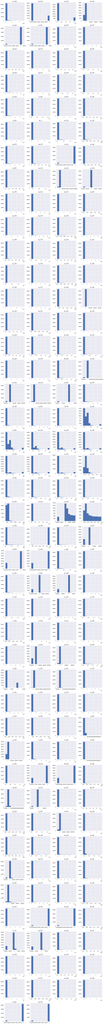

```python
# Histograms for each attribute before pre-processing
X_train_df[columns_to_scale].hist(layout=(dispRow,dispCol))
plt.show()
```

```python
# Apply feature scaling and transformation to the training dataset
scaler = preprocessing.MinMaxScaler()
scaled_features = scaler.fit_transform(X_train_df[columns_to_scale])
X_train_df.loc[:,tuple(columns_to_scale)] = scaled_features
print(X_train_df.head())
```

```
         aa_000    ab_000    ac_000    ad_000    ae_000    af_000    ag_000    ag_001    ag_002    ag_003    ag_004    ag_005    ag_006  \
53184  0.000796  0.000000  0.000047  0.140483  0.826103  0.832846  0.028761  0.023974  0.010742  0.002150  0.000576  0.000911  0.001509
38127  0.351795  0.997984  0.000057  0.140500  0.826103  0.832846  0.028761  0.023756  0.010820  0.055879  0.048248  0.050040  0.040355
23467  0.000007  0.000000  0.000047  0.140396  0.826103  0.832846  0.028761  0.023756  0.009387  0.001575  0.000437  0.000578  0.001106
34170  0.022194  0.000000  1.000000  0.140882  0.826103  0.832846  0.028761  0.023756  0.009387  0.001575  0.000617  0.009722  0.020297
55321  0.000004  0.997964  0.000047  0.140404  0.826103  0.832846  0.028761  0.023756  0.009387  0.001607  0.000446  0.000571  0.001076

         ag_007    ag_008    ag_009    ah_000    ai_000    aj_000    ak_000    al_000      am_0    an_000    ao_000    ap_000    aq_000  \
53184  0.001603  0.005617  0.005424  0.002242  0.006555  0.017454  0.009483  0.003839  0.002493  0.001703  0.001910  0.003680  0.004585
38127  0.025343  0.033918  0.009761  0.499171  0.007075  0.017454  0.000000  0.064987  0.056170  0.441690  0.405296  0.370144  0.529399
23467  0.001578  0.005617  0.005424  0.001380  0.006019  0.017510  0.009483  0.002968  0.001786  0.000809  0.000911  0.001407  0.003916
34170  0.002915  0.006202  0.005465  0.023260  0.006019  0.017454  0.009483  0.002968  0.001786  0.023960  0.024354  0.007403  0.016495
55321  0.001576  0.005617  0.005424  0.001371  0.006019  0.017454  0.009483  0.003007  0.001825  0.000750  0.000855  0.001364  0.003915

         ar_000    as_000    at_000    au_000    av_000    ax_000    ay_000   ay_001  ay_002    ay_003    ay_004    ay_005    ay_006  \
```

[output cut: 82 more lines]

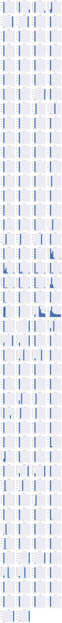

```python
# Histograms for each attribute after pre-processing
X_train_df[columns_to_scale].hist(layout=(dispRow,dispCol))
plt.show()
```

```python
# Apply feature scaling and transformation to the validation dataset
scaled_features = scaler.transform(X_validation_df[columns_to_scale])
X_validation_df.loc[:,tuple(columns_to_scale)] = scaled_features
print(X_validation_df.head())
```

```
             aa_000    ab_000    ac_000    ad_000    ae_000    af_000    ag_000    ag_001    ag_002    ag_003    ag_004    ag_005  \
33395  7.092498e-04  0.000000  0.000047  0.140432  0.826103  0.832846  0.028761  0.023756  0.009387  0.001575  0.000536  0.000746
24323  4.369095e-06  0.997964  0.000047  0.140404  0.826103  0.832846  0.028761  0.023756  0.009387  0.001585  0.000448  0.000565
3712   7.281826e-07  0.000000  0.000047  0.140415  0.826103  0.832846  0.028761  0.023756  0.009387  0.001659  0.000454  0.000566
56135  3.449182e-02  0.000000  0.000000  0.000000  0.000000  0.000000  0.028761  0.023756  0.009387  0.001575  0.000993  0.014459
7328   1.126790e-02  0.000000  0.000047  0.141109  0.826103  0.832846  0.028761  0.023756  0.009387  0.001575  0.000500  0.003284

         ag_006    ag_007    ag_008    ag_009    ah_000    ai_000    aj_000    ak_000    al_000      am_0    an_000    ao_000    ap_000  \
33395  0.001645  0.001577  0.005617  0.005424  0.002046  0.006019  0.017454  0.009483  0.002988  0.001809  0.001476  0.001640  0.001512
24323  0.001079  0.001576  0.005617  0.005424  0.001356  0.006019  0.017454  0.009483  0.002998  0.001825  0.000794  0.000905  0.001374
3712   0.001076  0.001576  0.005617  0.005424  0.001359  0.006019  0.017454  0.009483  0.002972  0.001792  0.000729  0.000837  0.001290
56135  0.034114  0.008482  0.005910  0.005424  0.032332  0.006019  0.017454  0.000000  0.003004  0.001834  0.038541  0.040476  0.013412
7328   0.013302  0.009062  0.009226  0.005973  0.014408  0.006019  0.017454  0.009483  0.002968  0.001786  0.014209  0.013602  0.007273

         aq_000    ar_000    as_000    at_000    au_000    av_000    ax_000    ay_000   ay_001  ay_002    ay_003    ay_004    ay_005  \
```

[output cut: 82 more lines]

```python
# Performing SMOTE transformation on the training data (Step #1 of 2)
X_train_imbal = X_train_df.to_numpy()
y_train_imbal = y_train_df.to_numpy()
print("X_train_imbal.shape: {} y_train_imbal.shape: {}".format(X_train_imbal.shape, y_train_imbal.shape))
```

```
X_train_imbal.shape: (45000, 170) y_train_imbal.shape: (45000,)
```

```python
# Performing SMOTE transformation on the training data (Step #2 of 2)
print ('Original class distribution - 1: {} | 0: {}'.format((y_train_imbal==1).sum(), (y_train_imbal==0).sum()))

over_sample = SMOTE(sampling_strategy=0.5, random_state=seedNum)
under_sample = RandomUnderSampler(sampling_strategy=1.0, random_state=seedNum)
steps = [('o', over_sample), ('u', under_sample)]
sample_pipeline = Pipeline(steps=steps)
X_train, y_train = sample_pipeline.fit_resample(X_train_imbal, y_train_imbal)

print ('Resampled class distribution - 1: {} | 0: {}'.format((y_train==1).sum(), (y_train==0).sum()))
```

```
Original class distribution - 1: 750 | 0: 44250
Resampled class distribution - 1: 22125 | 0: 22125
```

## 2.f) Display the Final Datasets for Model-Building

```python
# Finalize the training datasets for the modeling activities
X_validation = X_validation_df.to_numpy()
y_validation = y_validation_df.ravel()
print("X_train.shape: {} y_train.shape: {}".format(X_train.shape, y_train.shape))
print("X_validation.shape: {} y_validation.shape: {}".format(X_validation.shape, y_validation.shape))
```

```
X_train.shape: (44250, 170) y_train.shape: (44250,)
X_validation.shape: (15000, 170) y_validation.shape: (15000,)
```

# Task 3. Define and Train Model

```python
if (notifyStatus): status_notify("Task 3. Define and Train Model has begun! "+datetime.now().strftime('%a %B %d, %Y %I:%M:%S %p'))
```

```python
# Define the baseline model for benchmarking
def create_nn_model(layer1_nodes=48, layer2_nodes=32, layer3_nodes=24, layer4_nodes=16, layer5_nodes=8,
                    layer1_dropout=0, layer2_dropout=0, layer3_dropout=0, layer4_dropout=0, layer5_dropout=0,
                    opt_param=default_optimizer, init_param=default_kernel_init):
    nn_model = keras.Sequential()
    nn_model.add(keras.layers.Dense(layer1_nodes, input_shape=(X_train.shape[1],), activation='relu', kernel_initializer=init_param))
    nn_model.add(keras.layers.BatchNormalization())
    nn_model.add(keras.layers.Dropout(layer1_dropout))
    nn_model.add(keras.layers.Dense(layer2_nodes, activation='relu', kernel_initializer=init_param))
    nn_model.add(keras.layers.BatchNormalization())
    nn_model.add(keras.layers.Dropout(layer2_dropout))
    nn_model.add(keras.layers.Dense(layer3_nodes, activation='relu', kernel_initializer=init_param))
    nn_model.add(keras.layers.BatchNormalization())
    nn_model.add(keras.layers.Dropout(layer3_dropout))
    nn_model.add(keras.layers.Dense(layer4_nodes, activation='relu', kernel_initializer=init_param))
    nn_model.add(keras.layers.BatchNormalization())
    nn_model.add(keras.layers.Dropout(layer4_dropout))
    nn_model.add(keras.layers.Dense(layer5_nodes, activation='relu', kernel_initializer=init_param))
    nn_model.add(keras.layers.BatchNormalization())
    nn_model.add(keras.layers.Dropout(layer5_dropout))
    nn_model.add(keras.layers.Dense(1, activation='sigmoid', kernel_initializer=init_param))
    nn_model.compile(loss=default_loss, optimizer=opt_param, metrics=default_metrics)
    return nn_model
```

```python
# Define the function for plotting training results for comparison
def plot_metrics(history):
    fig, axs = plt.subplots(2, 2, figsize=(24, 12))
    metrics =  ['loss', 'auc', 'precision', 'recall']
    for n, metric in enumerate(metrics):
        name = metric.replace("_"," ").capitalize()
        plt.subplot(2,2,n+1)
        plt.plot(history.epoch,  history.history[metric], color='blue', label='Train')
        plt.plot(history.epoch, history.history['val_'+metric], color='red', linestyle="--", label='Val')
        plt.xlabel('Epoch')
        plt.ylabel(name)
        if metric == 'loss':
            plt.ylim([0, plt.ylim()[1]])
        elif metric == 'auc':
            plt.ylim([0.8,1])
        else:
            plt.ylim([0,1])
        plt.legend()
```

```python
# Initialize the default model and get a baseline result
startTimeModule = datetime.now()
reset_random(seedNum)
baseline_model = create_nn_model()
baseline_history = baseline_model.fit(X_train, y_train, epochs=default_epoch, batch_size=default_batch, validation_data=(X_validation, y_validation), verbose=1)
print('Total time for model fitting:', (datetime.now() - startTimeModule))
```

```
Total time for model fitting: 0:02:23.971839
```

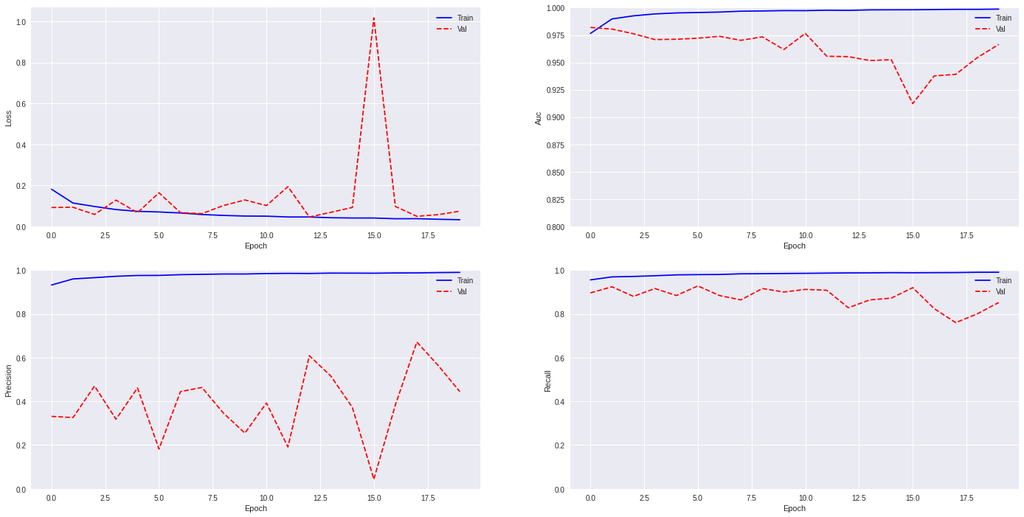

```python
plot_metrics(baseline_history)
```

```python
if (notifyStatus): status_notify("Task 3. Define and Train Model completed! "+datetime.now().strftime('%a %B %d, %Y %I:%M:%S %p'))
```

# Task 4. Evaluate and Optimize Model

```python
if (notifyStatus): status_notify("Task 4. Evaluate and Optimize Model has begun! "+datetime.now().strftime('%a %B %d, %Y %I:%M:%S %p'))
```

```python
# Initialize the grid parameters and fit the models
nodes_grid = [(72, 48, 36, 24, 12), (96, 64, 48, 32, 16), (120, 80, 60, 40, 20), (144, 96, 72, 48, 24), (192, 128, 96, 64, 32)]
layer1_dropout, layer2_dropout, layer3_dropout, layer4_dropout, layer5_dropout = (0, 0, 0, 0, 0)

# Build dataframe for reporting model performance summary
nodes_performance = pd.DataFrame(columns=['model_name', 'train_score', 'validation_score', 'variance', 'layer1_nodes', 'layer2_nodes', 'layer3_nodes', 'layer4_nodes',
                                          'layer5_nodes', 'layer1_dropout', 'layer2_dropout', 'layer3_dropout', 'layer4_dropout', 'layer5_dropout'])

serial_number = 0
for param in nodes_grid:
    startTimeModule = datetime.now()
    serial_number = serial_number + 1
    model_name = "Model_" + str(serial_number).zfill(3)
    layer1_nodes, layer2_nodes, layer3_nodes, layer4_nodes, layer5_nodes = param
    reset_random(seedNum)
    grid_search_model = create_nn_model(layer1_nodes, layer2_nodes, layer3_nodes, layer4_nodes, layer5_nodes, layer1_dropout, layer2_dropout,
                                        layer3_dropout, layer4_dropout, layer5_dropout, default_optimizer, default_kernel_init)
    print('Processing model %s with Layer 1: %d, Layer 2: %d, Layer 3: %d, Layer 4: %d, and Layer 5: %d nodes' % (model_name, layer1_nodes, layer2_nodes, layer3_nodes, layer4_nodes, layer5_nodes))
    model_train_hist = grid_search_model.fit(X_train, y_train, epochs=default_epoch, batch_size=default_batch, validation_data=(X_validation, y_validation), verbose=1)
    train_score = model_train_hist.history[train_metric][-1]
    validation_score = model_train_hist.history[validation_metric][-1]
    train_val_variance = abs(train_score - validation_score)
    print('The maximum score for the training dataset: %.2f%%' % (max(model_train_hist.history[train_metric])*100))
    print('The score at the last epoch for the training dataset: %.2f%%' % (train_score*100))
    print('The maximum score for the validation dataset: %.2f%%' % (max(model_train_hist.history[validation_metric])*100))
    print('The score at the last epoch for the validation dataset: %.2f%%' % (validation_score*100))
    print('The training vs. validation variance at the last epoch is: %.4f' % (train_val_variance))
    print('Total time for model fitting:', (datetime.now() - startTimeModule), '\n')
    nodes_performance = nodes_performance.append({'model_name': model_name, 'train_score': train_score, 'validation_score': validation_score, 'variance': train_val_variance,
                                                  'layer1_nodes': layer1_nodes, 'layer2_nodes': layer2_nodes, 'layer3_nodes': layer3_nodes, 'layer4_nodes': layer4_nodes,
                                                  'layer5_nodes': layer5_nodes, 'layer1_dropout': layer1_dropout, 'layer2_dropout': layer2_dropout, 'layer3_dropout': layer3_dropout,
                                                  'layer4_dropout': layer4_dropout, 'layer5_dropout': layer5_dropout}, ignore_index=True)

nodes_performance.set_index('model_name', inplace=True)
```

```
Processing model Model_001 with Layer 1: 72, Layer 2: 48, Layer 3: 36, Layer 4: 24, and Layer 5: 12 nodes
The maximum score for the training dataset: 99.17%
The score at the last epoch for the training dataset: 99.17%
The maximum score for the validation dataset: 92.40%
The score at the last epoch for the validation dataset: 86.80%
The training vs. validation variance at the last epoch is: 0.1237
Total time for model fitting: 0:02:21.472659

Processing model Model_002 with Layer 1: 96, Layer 2: 64, Layer 3: 48, Layer 4: 32, and Layer 5: 16 nodes
The maximum score for the training dataset: 99.20%
The score at the last epoch for the training dataset: 99.19%
The maximum score for the validation dataset: 93.60%
The score at the last epoch for the validation dataset: 82.40%
The training vs. validation variance at the last epoch is: 0.1679
Total time for model fitting: 0:02:20.190304

Processing model Model_003 with Layer 1: 120, Layer 2: 80, Layer 3: 60, Layer 4: 40, and Layer 5: 20 nodes
The maximum score for the training dataset: 99.23%
The score at the last epoch for the training dataset: 99.23%
The maximum score for the validation dataset: 89.60%
The score at the last epoch for the validation dataset: 80.00%
The training vs. validation variance at the last epoch is: 0.1923
Total time for model fitting: 0:02:22.288232

Processing model Model_004 with Layer 1: 144, Layer 2: 96, Layer 3: 72, Layer 4: 48, and Layer 5: 24 nodes
The maximum score for the training dataset: 99.29%
The score at the last epoch for the training dataset: 99.24%
The maximum score for the validation dataset: 93.60%
The score at the last epoch for the validation dataset: 81.20%
The training vs. validation variance at the last epoch is: 0.1804
Total time for model fitting: 0:02:17.920482

Processing model Model_005 with Layer 1: 192, Layer 2: 128, Layer 3: 96, Layer 4: 64, and Layer 5: 32 nodes
The maximum score for the training dataset: 99.35%
The score at the last epoch for the training dataset: 99.35%
The maximum score for the validation dataset: 92.40%
The score at the last epoch for the validation dataset: 84.40%
The training vs. validation variance at the last epoch is: 0.1495
Total time for model fitting: 0:02:19.569362
```

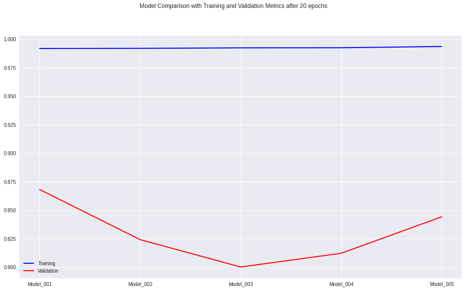

```python
# Spot-checking the models
fig = plt.figure(figsize=(16,9))
title = 'Model Comparison with Training and Validation Metrics after ' + str(default_epoch) + ' epochs'
fig.suptitle(title)
ax1 = fig.add_subplot(111)
ax1.plot(nodes_performance['train_score'], color='b', lw=2.)
ax1.plot(nodes_performance['validation_score'], color='r', lw=2.)
plt.legend(['Training', 'Validation'], loc='lower left')
plt.show()
```

```python
# Initialize the grid parameters for the dropout ratio
startTimeModule = datetime.now()
model_to_use = 'Model_001'
layer1_nodes = nodes_performance.loc[model_to_use]['layer1_nodes']
layer2_nodes = nodes_performance.loc[model_to_use]['layer2_nodes']
layer3_nodes = nodes_performance.loc[model_to_use]['layer3_nodes']
layer4_nodes = nodes_performance.loc[model_to_use]['layer4_nodes']
layer5_nodes = nodes_performance.loc[model_to_use]['layer5_nodes']
layer1_dropout_grid = [0.35, 0.5]
layer2_dropout_grid = [0.35, 0.5]
layer3_dropout_grid = [0.35, 0.5]
layer4_dropout_grid = [0.35, 0.5]
layer5_dropout_grid = [0.35, 0.5]

# Build dataframe for reporting model performance summary
dropout_performance = pd.DataFrame(columns=['model_name','train_score','validation_score','variance','layer1_nodes','layer2_nodes','layer3_nodes','layer4_nodes',
                                            'layer5_nodes','layer1_dropout','layer2_dropout','layer3_dropout','layer4_dropout','layer5_dropout'])

serial_number = 0
for layer1_dropout in layer1_dropout_grid:
    for layer2_dropout in layer2_dropout_grid:
        for layer3_dropout in layer3_dropout_grid:
            for layer4_dropout in layer4_dropout_grid:
                for layer5_dropout in layer5_dropout_grid:
                    startTimeIteration = datetime.now()
                    serial_number = serial_number + 1
                    model_name = "Model_" + str(serial_number).zfill(3)
                    reset_random(seedNum)
                    grid_search_model = create_nn_model(layer1_nodes, layer2_nodes, layer3_nodes, layer4_nodes, layer5_nodes, layer1_dropout, layer2_dropout,
                                                        layer3_dropout, layer4_dropout, layer5_dropout, default_optimizer, default_kernel_init)
                    print('Processing model %s with Layer 1: %d, Layer 2: %d, Layer 3: %d, Layer 4: %d, and Layer 5: %d nodes and dropout parameters of Layer 1: %.2f, Layer 2: %.2f, Layer 3: %.2f, Layer 4: %.2f, and Layer 5: %.2f' %
                        (model_name, layer1_nodes, layer2_nodes, layer3_nodes, layer4_nodes, layer5_nodes, layer1_dropout, layer2_dropout, layer3_dropout, layer4_dropout, layer5_dropout))
                    model_train_hist = grid_search_model.fit(X_train, y_train, epochs=default_epoch, batch_size=default_batch, validation_data=(X_validation, y_validation), verbose=0)
                    train_score = model_train_hist.history[train_metric][-1]
                    validation_score = model_train_hist.history[validation_metric][-1]
                    train_val_variance = abs(train_score - validation_score)
                    print('The maximum score for the training dataset: %.2f%%' % (max(model_train_hist.history[train_metric])*100))
                    print('The score at the last epoch for the training dataset: %.2f%%' % (train_score*100))
                    print('The maximum score for the validation dataset: %.2f%%' % (max(model_train_hist.history[validation_metric])*100))
                    print('The score at the last epoch for the validation dataset: %.2f%%' % (validation_score*100))
                    print('The training vs. validation variance at the last epoch is: %.4f' % (train_val_variance))
                    print('Total time for model fitting:', (datetime.now() - startTimeIteration), '\n')
                    dropout_performance = dropout_performance.append({'model_name': model_name, 'train_score': train_score, 'validation_score': validation_score, 'variance': train_val_variance,
                                                                    'layer1_nodes': layer1_nodes, 'layer2_nodes': layer2_nodes, 'layer3_nodes': layer3_nodes, 'layer4_nodes': layer4_nodes,
                                                                    'layer5_nodes': layer5_nodes, 'layer1_dropout': layer1_dropout, 'layer2_dropout': layer2_dropout, 'layer3_dropout': layer3_dropout,
                                                                    'layer4_dropout': layer4_dropout, 'layer5_dropout': layer5_dropout}, ignore_index=True)

dropout_performance.set_index('model_name', inplace=True)
print('Total time for performing grid-search of the best dropout parameters:', (datetime.now() - startTimeModule))
```

```
Processing model Model_001 with Layer 1: 72, Layer 2: 48, Layer 3: 36, Layer 4: 24, and Layer 5: 12 nodes and dropout parameters of Layer 1: 0.35, Layer 2: 0.35, Layer 3: 0.35, Layer 4: 0.35, and Layer 5: 0.35
The maximum score for the training dataset: 97.23%
The score at the last epoch for the training dataset: 97.23%
The maximum score for the validation dataset: 96.80%
The score at the last epoch for the validation dataset: 92.00%
The training vs. validation variance at the last epoch is: 0.0523
Total time for model fitting: 0:01:45.988200

Processing model Model_002 with Layer 1: 72, Layer 2: 48, Layer 3: 36, Layer 4: 24, and Layer 5: 12 nodes and dropout parameters of Layer 1: 0.35, Layer 2: 0.35, Layer 3: 0.35, Layer 4: 0.35, and Layer 5: 0.50
The maximum score for the training dataset: 97.41%
The score at the last epoch for the training dataset: 97.41%
The maximum score for the validation dataset: 97.20%
The score at the last epoch for the validation dataset: 90.00%
The training vs. validation variance at the last epoch is: 0.0741
Total time for model fitting: 0:01:44.820300

Processing model Model_003 with Layer 1: 72, Layer 2: 48, Layer 3: 36, Layer 4: 24, and Layer 5: 12 nodes and dropout parameters of Layer 1: 0.35, Layer 2: 0.35, Layer 3: 0.35, Layer 4: 0.50, and Layer 5: 0.35
The maximum score for the training dataset: 97.03%
The score at the last epoch for the training dataset: 97.03%
The maximum score for the validation dataset: 96.40%
The score at the last epoch for the validation dataset: 92.00%
The training vs. validation variance at the last epoch is: 0.0503
Total time for model fitting: 0:01:42.433670

Processing model Model_004 with Layer 1: 72, Layer 2: 48, Layer 3: 36, Layer 4: 24, and Layer 5: 12 nodes and dropout parameters of Layer 1: 0.35, Layer 2: 0.35, Layer 3: 0.35, Layer 4: 0.50, and Layer 5: 0.50
The maximum score for the training dataset: 97.25%
The score at the last epoch for the training dataset: 97.25%
The maximum score for the validation dataset: 96.40%
The score at the last epoch for the validation dataset: 92.80%
The training vs. validation variance at the last epoch is: 0.0445
Total time for model fitting: 0:01:42.775690

Processing model Model_005 with Layer 1: 72, Layer 2: 48, Layer 3: 36, Layer 4: 24, and Layer 5: 12 nodes and dropout parameters of Layer 1: 0.35, Layer 2: 0.35, Layer 3: 0.50, Layer 4: 0.35, and Layer 5: 0.35
The maximum score for the training dataset: 97.09%
The score at the last epoch for the training dataset: 97.09%
The maximum score for the validation dataset: 96.00%
The score at the last epoch for the validation dataset: 89.60%
The training vs. validation variance at the last epoch is: 0.0749
Total time for model fitting: 0:01:42.376198

```

[output cut: 202 more lines]

```
The score at the last epoch for the training dataset: 96.54%
The maximum score for the validation dataset: 96.80%
The score at the last epoch for the validation dataset: 92.40%
The training vs. validation variance at the last epoch is: 0.0414
Total time for model fitting: 0:01:47.383957

Processing model Model_032 with Layer 1: 72, Layer 2: 48, Layer 3: 36, Layer 4: 24, and Layer 5: 12 nodes and dropout parameters of Layer 1: 0.50, Layer 2: 0.50, Layer 3: 0.50, Layer 4: 0.50, and Layer 5: 0.50
The maximum score for the training dataset: 96.34%
The score at the last epoch for the training dataset: 96.25%
The maximum score for the validation dataset: 96.80%
The score at the last epoch for the validation dataset: 90.80%
The training vs. validation variance at the last epoch is: 0.0545
Total time for model fitting: 0:01:47.853812

Total time for performing grid-search of the best dropout parameters: 0:55:17.852510
```

```python
# Display the model performance summary by validation score
dropout_performance.sort_values(by=['validation_score'], ascending=False).head()
```

| model_name | train_score | validation_score | variance | layer1_nodes | layer2_nodes | layer3_nodes | layer4_nodes | layer5_nodes | layer1_dropout | layer2_dropout | layer3_dropout | layer4_dropout | layer5_dropout |
| --- | --- | --- | --- | --- | --- | --- | --- | --- | --- | --- | --- | --- | --- |
| Model_008 | 0.972158 | 0.944 | 0.028158 | 72 | 48 | 36 | 24 | 12 | 0.35 | 0.35 | 0.50 | 0.50 | 0.50 |
| Model_026 | 0.968226 | 0.944 | 0.024226 | 72 | 48 | 36 | 24 | 12 | 0.50 | 0.50 | 0.35 | 0.35 | 0.50 |
| Model_027 | 0.964746 | 0.944 | 0.020746 | 72 | 48 | 36 | 24 | 12 | 0.50 | 0.50 | 0.35 | 0.50 | 0.35 |
| Model_023 | 0.965695 | 0.936 | 0.029695 | 72 | 48 | 36 | 24 | 12 | 0.50 | 0.35 | 0.50 | 0.50 | 0.35 |
| Model_025 | 0.969266 | 0.932 | 0.037266 | 72 | 48 | 36 | 24 | 12 | 0.50 | 0.50 | 0.35 | 0.35 | 0.35 |

```python
# Display the model performance summary by variance
dropout_performance.sort_values(by=['variance']).head()
```

| model_name | train_score | validation_score | variance | layer1_nodes | layer2_nodes | layer3_nodes | layer4_nodes | layer5_nodes | layer1_dropout | layer2_dropout | layer3_dropout | layer4_dropout | layer5_dropout |
| --- | --- | --- | --- | --- | --- | --- | --- | --- | --- | --- | --- | --- | --- |
| Model_027 | 0.964746 | 0.944 | 0.020746 | 72 | 48 | 36 | 24 | 12 | 0.50 | 0.50 | 0.35 | 0.50 | 0.35 |
| Model_026 | 0.968226 | 0.944 | 0.024226 | 72 | 48 | 36 | 24 | 12 | 0.50 | 0.50 | 0.35 | 0.35 | 0.50 |
| Model_008 | 0.972158 | 0.944 | 0.028158 | 72 | 48 | 36 | 24 | 12 | 0.35 | 0.35 | 0.50 | 0.50 | 0.50 |
| Model_023 | 0.965695 | 0.936 | 0.029695 | 72 | 48 | 36 | 24 | 12 | 0.50 | 0.35 | 0.50 | 0.50 | 0.35 |
| Model_025 | 0.969266 | 0.932 | 0.037266 | 72 | 48 | 36 | 24 | 12 | 0.50 | 0.50 | 0.35 | 0.35 | 0.35 |

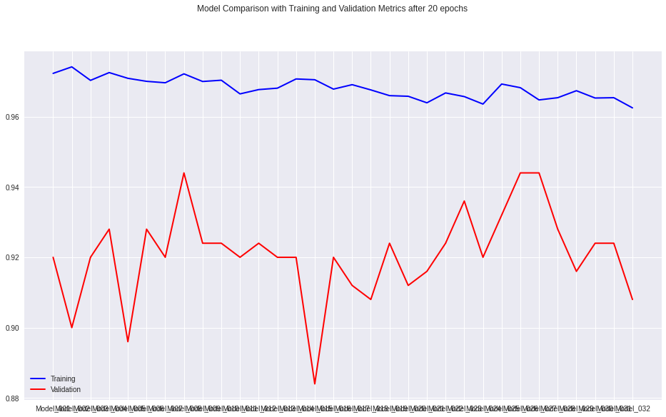

```python
# Spot-checking the models
fig = plt.figure(figsize=(16,9))
title = 'Model Comparison with Training and Validation Metrics after ' + str(default_epoch) + ' epochs'
fig.suptitle(title)
ax1 = fig.add_subplot(111)
ax1.plot(dropout_performance['train_score'], color='b', lw=2.)
ax1.plot(dropout_performance['validation_score'], color='r', lw=2.)
plt.legend(['Training', 'Validation'], loc='lower left')
plt.show()
```

```python
# Initialize the grid parameters for the optimizer, kernel, and batch size
startTimeModule = datetime.now()
model_to_use = 'Model_008'
layer1_nodes = dropout_performance.loc[model_to_use]['layer1_nodes']
layer2_nodes = dropout_performance.loc[model_to_use]['layer2_nodes']
layer3_nodes = dropout_performance.loc[model_to_use]['layer3_nodes']
layer4_nodes = dropout_performance.loc[model_to_use]['layer4_nodes']
layer5_nodes = dropout_performance.loc[model_to_use]['layer5_nodes']
layer1_dropout = dropout_performance.loc[model_to_use]['layer1_dropout']
layer2_dropout = dropout_performance.loc[model_to_use]['layer2_dropout']
layer3_dropout = dropout_performance.loc[model_to_use]['layer3_dropout']
layer4_dropout = dropout_performance.loc[model_to_use]['layer4_dropout']
layer5_dropout = dropout_performance.loc[model_to_use]['layer5_dropout']

# Set up grid search using different epochs, batch sizes, and optimizers
optz_1 = tf.keras.optimizers.Adam(learning_rate=0.001)
optz_2 = tf.keras.optimizers.RMSprop(learning_rate=0.001)
optz_3 = tf.keras.optimizers.SGD(learning_rate=0.01)
optimizer_grid = [optz_1, optz_2, optz_3]
print('Optimizer candidate #1 has the object ID of', optz_1)
print('Optimizer candidate #2 has the object ID of', optz_2)
print('Optimizer candidate #3 has the object ID of', optz_3)

init_1 = tf.keras.initializers.he_uniform(seed=seedNum)
init_2 = tf.keras.initializers.Orthogonal(seed=seedNum)
init_3 = tf.keras.initializers.RandomUniform(seed=seedNum)
init_grid = [init_1, init_2, init_3]
print('Initializer candidate #1 has the object ID of', init_1)
print('Initializer candidate #2 has the object ID of', init_2)
print('Initializer candidate #3 has the object ID of', init_3)

epoch_grid = [default_epoch]
batch_grid = [default_batch]

grid_iteration = 1
best_score = 0
best_iteration = 0
best_optimizer = default_optimizer
best_kernel_init = default_kernel_init
best_epoch = default_epoch
best_batch = default_batch

for optimizer in optimizer_grid:
    for kernel_init in init_grid:
        for epoch_num in epoch_grid:
            for batch_num in batch_grid:
                startTimeIteration = datetime.now()
                print('\nForming the grid-search model #%d using: optimizer=%s, kernel=%s, epochs=%d, batch_size=%d'
                      % (grid_iteration, optimizer, kernel_init, epoch_num, batch_num))
                reset_random(seedNum)
                grid_model = create_nn_model(layer1_nodes, layer2_nodes, layer3_nodes, layer4_nodes, layer5_nodes, layer1_dropout, layer2_dropout,
                                             layer3_dropout, layer4_dropout, layer5_dropout, optimizer, kernel_init)
                grid_hist = grid_model.fit(X_train, y_train, epochs=epoch_num, batch_size=batch_num, validation_data=(X_validation, y_validation), verbose=0)
                train_score = grid_hist.history[train_metric][-1]
                validation_score = grid_hist.history[validation_metric][-1]
                train_val_variance = abs(train_score - validation_score)
                print('The maximum score for the training dataset: %.2f%%' % (max(grid_hist.history[train_metric])*100))
                print('The score at the last epoch for the training dataset: %.2f%%' % (train_score*100))
                print('The maximum score for the validation dataset: %.2f%%' % (max(grid_hist.history[validation_metric])*100))
                print('The score at the last epoch for the validation dataset: %.2f%%' % (validation_score*100))
                print('The training vs. validation variance at the last epoch is: %.4f' % (train_val_variance))
                print('Total time for model fitting:', (datetime.now() - startTimeIteration), '\n')
                if(grid_hist.history[validation_metric][-1] > best_score):
                    best_score = grid_hist.history[validation_metric][-1]
                    best_iteration = grid_iteration
                    best_optimizer = optimizer
                    best_kernel_init = kernel_init
                    best_epoch = epoch_num
                    best_batch = batch_num
                grid_iteration = grid_iteration + 1

# summarize results
print("\nBest score (from validation) found via grid search: %f from model iteration #%d"
      % (best_score, best_iteration))
print('The best modeling parameters are: optimizer=%s, kernel=%s, epochs=%d, batch_size=%d'
      % (best_optimizer, best_kernel_init, best_epoch, best_batch))
print('Total time for performing grid-search of the best parameters:', (datetime.now() - startTimeModule))
```

```
Optimizer candidate #1 has the object ID of <tensorflow.python.keras.optimizer_v2.adam.Adam object at 0x7f00b29a8470>
Optimizer candidate #2 has the object ID of <tensorflow.python.keras.optimizer_v2.rmsprop.RMSprop object at 0x7f00b29a8940>
Optimizer candidate #3 has the object ID of <tensorflow.python.keras.optimizer_v2.gradient_descent.SGD object at 0x7f00b29a8898>
Initializer candidate #1 has the object ID of <tensorflow.python.ops.init_ops_v2.VarianceScaling object at 0x7f00b29a8b70>
Initializer candidate #2 has the object ID of <tensorflow.python.ops.init_ops_v2.Orthogonal object at 0x7f00b29a8d30>
Initializer candidate #3 has the object ID of <tensorflow.python.ops.init_ops_v2.RandomUniform object at 0x7f00b29a8f60>

Forming the grid-search model #1 using: optimizer=<tensorflow.python.keras.optimizer_v2.adam.Adam object at 0x7f00b29a8470>, kernel=<tensorflow.python.ops.init_ops_v2.VarianceScaling object at 0x7f00b29a8b70>, epochs=20, batch_size=64
The maximum score for the training dataset: 96.82%
The score at the last epoch for the training dataset: 96.82%
The maximum score for the validation dataset: 97.20%
The score at the last epoch for the validation dataset: 95.60%
The training vs. validation variance at the last epoch is: 0.0122
Total time for model fitting: 0:01:49.234038


Forming the grid-search model #2 using: optimizer=<tensorflow.python.keras.optimizer_v2.adam.Adam object at 0x7f00b29a8470>, kernel=<tensorflow.python.ops.init_ops_v2.Orthogonal object at 0x7f00b29a8d30>, epochs=20, batch_size=64
The maximum score for the training dataset: 97.08%
The score at the last epoch for the training dataset: 97.08%
The maximum score for the validation dataset: 96.00%
The score at the last epoch for the validation dataset: 96.00%
The training vs. validation variance at the last epoch is: 0.0108
Total time for model fitting: 0:01:48.440099


Forming the grid-search model #3 using: optimizer=<tensorflow.python.keras.optimizer_v2.adam.Adam object at 0x7f00b29a8470>, kernel=<tensorflow.python.ops.init_ops_v2.RandomUniform object at 0x7f00b29a8f60>, epochs=20, batch_size=64
The maximum score for the training dataset: 96.96%
The score at the last epoch for the training dataset: 96.96%
The maximum score for the validation dataset: 96.40%
The score at the last epoch for the validation dataset: 90.40%
The training vs. validation variance at the last epoch is: 0.0656
Total time for model fitting: 0:01:48.131867


Forming the grid-search model #4 using: optimizer=<tensorflow.python.keras.optimizer_v2.rmsprop.RMSprop object at 0x7f00b29a8940>, kernel=<tensorflow.python.ops.init_ops_v2.VarianceScaling object at 0x7f00b29a8b70>, epochs=20, batch_size=64
The maximum score for the training dataset: 97.36%
The score at the last epoch for the training dataset: 97.28%
The maximum score for the validation dataset: 95.60%
The score at the last epoch for the validation dataset: 93.60%
The training vs. validation variance at the last epoch is: 0.0368
```

[output cut: 36 more lines]

```
Total time for model fitting: 0:01:45.394259


Forming the grid-search model #9 using: optimizer=<tensorflow.python.keras.optimizer_v2.gradient_descent.SGD object at 0x7f00b29a8898>, kernel=<tensorflow.python.ops.init_ops_v2.RandomUniform object at 0x7f00b29a8f60>, epochs=20, batch_size=64
The maximum score for the training dataset: 95.86%
The score at the last epoch for the training dataset: 95.86%
The maximum score for the validation dataset: 98.00%
The score at the last epoch for the validation dataset: 92.00%
The training vs. validation variance at the last epoch is: 0.0386
Total time for model fitting: 0:01:46.344412


Best score (from validation) found via grid search: 0.960000 from model iteration #2
The best modeling parameters are: optimizer=<tensorflow.python.keras.optimizer_v2.adam.Adam object at 0x7f00b29a8470>, kernel=<tensorflow.python.ops.init_ops_v2.Orthogonal object at 0x7f00b29a8d30>, epochs=20, batch_size=64
Total time for performing grid-search of the best parameters: 0:16:53.424970
```

```python
if (notifyStatus): status_notify("Task 4. Evaluate and Optimize Model completed! "+datetime.now().strftime('%a %B %d, %Y %I:%M:%S %p'))
```

# Task 5. Finalize Model and Make Predictions

```python
if (notifyStatus): status_notify("Task 5. Finalize Model and Make Predictions has begun! "+datetime.now().strftime('%a %B %d, %Y %I:%M:%S %p'))
```

```python
# Combining the training and validation datasets to form the dataset that will be used for training the final model
X_train_val = np.vstack((X_train, X_validation))
y_train_val = np.concatenate((y_train, y_validation))
print("X_train_val.shape: {} y_train_val.shape: {}".format(X_train_val.shape, y_train_val.shape))
```

```
X_train_val.shape: (59250, 170) y_train_val.shape: (59250,)
```

```python
# Create the final model for evaluating the test dataset
final_optimizer = best_optimizer
final_kernel_init = best_kernel_init
final_epoch = best_epoch
final_batch = best_batch
print('Processing model %s with Layer 1: %d, Layer 2: %d, Layer 3: %d, Layer 4: %d, and Layer 5: %d nodes and dropout parameters of Layer 1: %.2f, Layer 2: %.2f, Layer 3: %.2f, Layer 4: %.2f, and Layer 5: %.2f' %
      (model_name, layer1_nodes, layer2_nodes, layer3_nodes, layer4_nodes, layer5_nodes, layer1_dropout, layer2_dropout, layer3_dropout, layer4_dropout, layer5_dropout))
print('The final modeling parameters are: optimizer=%s, kernel=%s, epochs=%d, batch_size=%d' % (best_optimizer, best_kernel_init, best_epoch, best_batch))
reset_random(seedNum)
final_model = create_nn_model(layer1_nodes, layer2_nodes, layer3_nodes, layer4_nodes, layer5_nodes, layer1_dropout, layer2_dropout, layer3_dropout, layer4_dropout, layer5_dropout, final_optimizer, final_kernel_init)
final_model.fit(X_train_val, y_train_val, epochs=default_epoch, batch_size=default_batch, verbose=0)

# Display a summary of the final model
print(final_model.summary())
```

```
Processing model Model_032 with Layer 1: 72, Layer 2: 48, Layer 3: 36, Layer 4: 24, and Layer 5: 12 nodes and dropout parameters of Layer 1: 0.35, Layer 2: 0.35, Layer 3: 0.50, Layer 4: 0.50, and Layer 5: 0.50
The final modeling parameters are: optimizer=<tensorflow.python.keras.optimizer_v2.adam.Adam object at 0x7f00b29a8470>, kernel=<tensorflow.python.ops.init_ops_v2.Orthogonal object at 0x7f00b29a8d30>, epochs=20, batch_size=64
Model: "sequential_47"
_________________________________________________________________
Layer (type)                 Output Shape              Param #
=================================================================
dense_282 (Dense)            (None, 72)                12312
_________________________________________________________________
batch_normalization_235 (Bat (None, 72)                288
_________________________________________________________________
dropout_235 (Dropout)        (None, 72)                0
_________________________________________________________________
dense_283 (Dense)            (None, 48)                3504
_________________________________________________________________
batch_normalization_236 (Bat (None, 48)                192
_________________________________________________________________
dropout_236 (Dropout)        (None, 48)                0
_________________________________________________________________
dense_284 (Dense)            (None, 36)                1764
_________________________________________________________________
batch_normalization_237 (Bat (None, 36)                144
_________________________________________________________________
dropout_237 (Dropout)        (None, 36)                0
_________________________________________________________________
dense_285 (Dense)            (None, 24)                888
_________________________________________________________________
batch_normalization_238 (Bat (None, 24)                96
_________________________________________________________________
dropout_238 (Dropout)        (None, 24)                0
_________________________________________________________________
dense_286 (Dense)            (None, 12)                300
_________________________________________________________________
batch_normalization_239 (Bat (None, 12)                48
_________________________________________________________________
dropout_239 (Dropout)        (None, 12)                0
_________________________________________________________________
dense_287 (Dense)            (None, 1)                 13
=================================================================
Total params: 19,549
Trainable params: 19,165
Non-trainable params: 384
_________________________________________________________________
None
```

```python
dataset_path = 'https://dainesanalytics.com/datasets/ucirvine-truck-aps-failure/aps_failure_test_set.csv'
Xy_test = pd.read_csv(dataset_path, sep=',', na_values="na", skiprows=19)

# Take a peek at the dataframe after import
Xy_test.head()
```

|  | class | aa_000 | ab_000 | ac_000 | ad_000 | ae_000 | af_000 | ag_000 | ag_001 | ag_002 | ag_003 | ag_004 | ag_005 | ag_006 | ag_007 | ag_008 | ag_009 | ah_000 | ai_000 | aj_000 | ak_000 | al_000 | am_0 | an_000 | ao_000 | ap_000 | aq_000 | ar_000 | as_000 | … |
| --- | --- | --- | --- | --- | --- | --- | --- | --- | --- | --- | --- | --- | --- | --- | --- | --- | --- | --- | --- | --- | --- | --- | --- | --- | --- | --- | --- | --- | --- | --- |
| 0 | neg | 60 | 0.0 | 20.0 | 12.0 | 0.0 | 0.0 | 0.0 | 0.0 | 0.0 | 2682.0 | 4736.0 | 3862.0 | 1846.0 | 0.0 | 0.0 | 0.0 | 3976.0 | 0.0 | 0.0 | 0.0 | 1520.0 | 2374.0 | 11516.0 | 9480.0 | 111258.0 | 470.0 | 0.0 | 0.0 | … |
| 1 | neg | 82 | 0.0 | 68.0 | 40.0 | 0.0 | 0.0 | 0.0 | 0.0 | 0.0 | 0.0 | 748.0 | 12594.0 | 3636.0 | 0.0 | 0.0 | 0.0 | 5244.0 | 0.0 | 60.0 | 0.0 | 0.0 | 0.0 | 23174.0 | 18166.0 | 23686.0 | 1270.0 | 0.0 | 0.0 | … |
| 2 | neg | 66002 | 2.0 | 212.0 | 112.0 | 0.0 | 0.0 | 0.0 | 0.0 | 0.0 | 199486.0 | 1358536.0 | 1952422.0 | 452706.0 | 25130.0 | 520.0 | 0.0 | 1891670.0 | 0.0 | 0.0 | 0.0 | 77898.0 | 110548.0 | 3605894.0 | 3291610.0 | 959756.0 | 286536.0 | 0.0 | 0.0 | … |
| 3 | neg | 59816 | NaN | 1010.0 | 936.0 | 0.0 | 0.0 | 0.0 | 0.0 | 0.0 | 0.0 | 123922.0 | 984314.0 | 1680050.0 | 1135268.0 | 92606.0 | 14038.0 | 1772828.0 | 0.0 | 0.0 | 0.0 | 1116.0 | 2372.0 | 3546760.0 | 3053176.0 | 652616.0 | 423374.0 | 0.0 | 0.0 | … |
| 4 | neg | 1814 | NaN | 156.0 | 140.0 | 0.0 | 0.0 | 0.0 | 0.0 | 0.0 | 0.0 | 72.0 | 17926.0 | 82834.0 | 3114.0 | 0.0 | 0.0 | 48978.0 | 0.0 | 0.0 | 0.0 | 0.0 | 0.0 | 97146.0 | 89920.0 | 12932.0 | 5092.0 | 0.0 | 0.0 | … |

```python
Xy_test.isnull().sum()
```

```
class         0
aa_000        0
ab_000    12363
ac_000      926
ad_000     3981
ae_000      690
af_000      690
ag_000      189
ag_001      189
ag_002      189
ag_003      189
ag_004      189
ag_005      189
ag_006      189
ag_007      189
ag_008      189
ag_009      189
ah_000      175
ai_000      163
aj_000      163
ak_000     1198
al_000      169
am_0        163
an_000      169
ao_000      162
ap_000      169
aq_000      162
ar_000      764
as_000      163
at_000      163
au_000      163
av_000      688
ax_000      688
ay_000      192
ay_001      192
ay_002      192
ay_003      192
ay_004      192
ay_005      192
ay_006      192
```

[output cut: 117 more lines]

```
ec_00      2644
ed_000     2459
ee_000      192
ee_001      192
ee_002      192
ee_003      192
ee_004      192
ee_005      192
ee_006      192
ee_007      192
ee_008      192
ee_009      192
ef_000      762
eg_000      762
dtype: int64
```

```python
print('Total number of NaN in the dataframe: ', Xy_test.isnull().sum().sum())
```

```
Total number of NaN in the dataframe:  228680
```

```python
# Impute missing values
Xy_test.fillna(-99999.0, inplace=True)

# Convert columns from one data type to another
Xy_test['aa_000'] = Xy_test['aa_000'].astype('float')

# Convert class variable with pos/neg levels into categorical feature of 0/1
def reclass_somecol(target):
    if target == 'pos': return 1
    else: return 0
Xy_test['targetVar'] = Xy_test['class'].apply(reclass_somecol)
Xy_test.drop(columns=['class'], inplace=True)

# Take a peek at the dataframe after cleaning
Xy_test.head()
```

|  | aa_000 | ab_000 | ac_000 | ad_000 | ae_000 | af_000 | ag_000 | ag_001 | ag_002 | ag_003 | ag_004 | ag_005 | ag_006 | ag_007 | ag_008 | ag_009 | ah_000 | ai_000 | aj_000 | ak_000 | al_000 | am_0 | an_000 | ao_000 | ap_000 | aq_000 | ar_000 | as_000 | at_000 | … |
| --- | --- | --- | --- | --- | --- | --- | --- | --- | --- | --- | --- | --- | --- | --- | --- | --- | --- | --- | --- | --- | --- | --- | --- | --- | --- | --- | --- | --- | --- | --- |
| 0 | 60.0 | 0.0 | 20.0 | 12.0 | 0.0 | 0.0 | 0.0 | 0.0 | 0.0 | 2682.0 | 4736.0 | 3862.0 | 1846.0 | 0.0 | 0.0 | 0.0 | 3976.0 | 0.0 | 0.0 | 0.0 | 1520.0 | 2374.0 | 11516.0 | 9480.0 | 111258.0 | 470.0 | 0.0 | 0.0 | 0.0 | … |
| 1 | 82.0 | 0.0 | 68.0 | 40.0 | 0.0 | 0.0 | 0.0 | 0.0 | 0.0 | 0.0 | 748.0 | 12594.0 | 3636.0 | 0.0 | 0.0 | 0.0 | 5244.0 | 0.0 | 60.0 | 0.0 | 0.0 | 0.0 | 23174.0 | 18166.0 | 23686.0 | 1270.0 | 0.0 | 0.0 | 0.0 | … |
| 2 | 66002.0 | 2.0 | 212.0 | 112.0 | 0.0 | 0.0 | 0.0 | 0.0 | 0.0 | 199486.0 | 1358536.0 | 1952422.0 | 452706.0 | 25130.0 | 520.0 | 0.0 | 1891670.0 | 0.0 | 0.0 | 0.0 | 77898.0 | 110548.0 | 3605894.0 | 3291610.0 | 959756.0 | 286536.0 | 0.0 | 0.0 | 0.0 | … |
| 3 | 59816.0 | -99999.0 | 1010.0 | 936.0 | 0.0 | 0.0 | 0.0 | 0.0 | 0.0 | 0.0 | 123922.0 | 984314.0 | 1680050.0 | 1135268.0 | 92606.0 | 14038.0 | 1772828.0 | 0.0 | 0.0 | 0.0 | 1116.0 | 2372.0 | 3546760.0 | 3053176.0 | 652616.0 | 423374.0 | 0.0 | 0.0 | 7274.0 | … |
| 4 | 1814.0 | -99999.0 | 156.0 | 140.0 | 0.0 | 0.0 | 0.0 | 0.0 | 0.0 | 0.0 | 72.0 | 17926.0 | 82834.0 | 3114.0 | 0.0 | 0.0 | 48978.0 | 0.0 | 0.0 | 0.0 | 0.0 | 0.0 | 97146.0 | 89920.0 | 12932.0 | 5092.0 | 0.0 | 0.0 | 0.0 | … |

```python
Xy_test.info(verbose=True)
```

```
<class 'pandas.core.frame.DataFrame'>
RangeIndex: 16000 entries, 0 to 15999
Data columns (total 171 columns):
 #   Column     Dtype
---  ------     -----
 0   aa_000     float64
 1   ab_000     float64
 2   ac_000     float64
 3   ad_000     float64
 4   ae_000     float64
 5   af_000     float64
 6   ag_000     float64
 7   ag_001     float64
 8   ag_002     float64
 9   ag_003     float64
```

[output cut: 163 more lines]

```python
print(Xy_test.describe())
```

```
             aa_000        ab_000        ac_000        ad_000        ae_000        af_000         ag_000        ag_001        ag_002  \
count  1.600000e+04  16000.000000  1.600000e+04  16000.000000  16000.000000  16000.000000   16000.000000  1.600000e+04  1.600000e+04
mean   6.799698e+04 -77267.801812  3.373120e+08 -24550.855188  -4306.305750  -4302.700625   -1061.807313  8.585821e+02  1.244820e+04
std    5.035350e+05  41910.822592  7.778065e+08  43444.234143  20315.912635  20317.007863   12577.258025  8.941163e+04  2.347655e+05
min    0.000000e+00 -99999.000000 -9.999900e+04 -99999.000000 -99999.000000 -99999.000000  -99999.000000 -9.999900e+04 -9.999900e+04
25%    9.280000e+02 -99999.000000  8.000000e+00      0.000000      0.000000      0.000000       0.000000  0.000000e+00  0.000000e+00
50%    3.098200e+04 -99999.000000  1.240000e+02     42.000000      0.000000      0.000000       0.000000  0.000000e+00  0.000000e+00
75%    4.947900e+04 -99999.000000  8.520000e+02    298.000000      0.000000      0.000000       0.000000  0.000000e+00  0.000000e+00
max    4.294967e+07     58.000000  2.130707e+09  87038.000000  11044.000000  14186.000000  736174.000000  1.047252e+07  1.914916e+07

             ag_003        ag_004        ag_005        ag_006        ag_007        ag_008        ag_009        ah_000        ai_000  \
count  1.600000e+04  1.600000e+04  1.600000e+04  1.600000e+04  1.600000e+04  1.600000e+04  1.600000e+04  1.600000e+04  1.600000e+04
mean   1.101159e+05  4.835662e+05  1.160784e+06  1.676755e+06  4.992072e+05  3.431601e+04  4.535277e+03  1.895661e+06  1.063389e+04
std    1.020024e+06  2.778701e+06  3.625005e+06  4.044554e+06  1.386183e+06  2.410876e+05  1.707753e+05  4.536076e+06  2.259121e+05
min   -9.999900e+04 -9.999900e+04 -9.999900e+04 -9.999900e+04 -9.999900e+04 -9.999900e+04 -9.999900e+04 -9.999900e+04 -9.999900e+04
25%    0.000000e+00  2.900000e+02  1.312000e+04  1.024300e+04  0.000000e+00  0.000000e+00  0.000000e+00  2.928150e+04  0.000000e+00
50%    0.000000e+00  3.519000e+03  1.716900e+05  9.102480e+05  1.070430e+05  1.504000e+03  0.000000e+00  1.000639e+06  0.000000e+00
75%    0.000000e+00  5.118950e+04  9.109680e+05  1.881622e+06  5.904850e+05  2.727050e+04  3.885000e+02  1.597286e+06  0.000000e+00
max    7.305747e+07  1.895324e+08  1.685347e+08  7.691299e+07  3.499815e+07  1.758501e+07  1.398098e+07  8.207358e+07  1.777009e+07

             aj_000        ak_000        al_000          am_0        an_000        ao_000        ap_000        aq_000        ar_000  \
count  1.600000e+04  1.600000e+04  1.600000e+04  1.600000e+04  1.600000e+04  1.600000e+04  1.600000e+04  1.600000e+04  16000.000000
mean   2.238627e+02 -6.627688e+03  6.908238e+04  1.099421e+05  3.620982e+06  3.145763e+06  1.063935e+06  4.688439e+05  -4774.497375
std    5.233197e+04  9.105088e+04  6.460373e+05  1.007742e+06  8.436377e+06  7.400086e+06  3.409613e+06  1.374144e+06  21324.236573
min   -9.999900e+04 -9.999900e+04 -9.999900e+04 -9.999900e+04 -9.999900e+04 -9.999900e+04 -9.999900e+04 -9.999900e+04 -99999.000000
25%    0.000000e+00  0.000000e+00  0.000000e+00  0.000000e+00  7.306400e+04  6.567400e+04  2.485550e+04  4.142000e+03      0.000000
50%    0.000000e+00  0.000000e+00  0.000000e+00  0.000000e+00  1.911924e+06  1.647781e+06  3.548330e+05  1.803600e+05      0.000000
75%    0.000000e+00  0.000000e+00  1.252500e+03  2.470000e+03  3.128904e+06  2.684105e+06  7.255655e+05  3.759855e+05      0.000000
max    3.913164e+06  1.093059e+07  3.777930e+07  5.556690e+07  1.498686e+08  1.427517e+08  1.156131e+08  3.455877e+07    188.000000

             as_000        at_000        au_000         av_000       ax_000        ay_000        ay_001        ay_002        ay_003  \
count  1.600000e+04  1.600000e+04  1.600000e+04   16000.000000  16000.00000  1.600000e+04  1.600000e+04  1.600000e+04  1.600000e+04
mean  -3.264277e+02  4.587679e+03 -4.645072e+02   -3102.726875  -3929.47650  2.375376e+04  1.424172e+04  1.141430e+04  6.390739e+03
std    5.848860e+04  1.264450e+05  4.839876e+04   21684.017302  20417.50204  1.005860e+06  6.463890e+05  4.687802e+05  2.155255e+05
min   -9.999900e+04 -9.999900e+04 -9.999900e+04  -99999.000000 -99999.00000 -9.999900e+04 -9.999900e+04 -9.999900e+04 -9.999900e+04
25%    0.000000e+00  0.000000e+00  0.000000e+00       6.000000      6.00000  0.000000e+00  0.000000e+00  0.000000e+00  0.000000e+00
50%    0.000000e+00  0.000000e+00  0.000000e+00      96.000000     60.00000  0.000000e+00  0.000000e+00  0.000000e+00  0.000000e+00
75%    0.000000e+00  0.000000e+00  0.000000e+00     610.000000    254.00000  0.000000e+00  0.000000e+00  0.000000e+00  0.000000e+00
max    6.383704e+06  1.065435e+07  5.711474e+06  299810.000000  53572.00000  7.404109e+07  5.835158e+07  3.023117e+07  1.251085e+07

```

[output cut: 134 more lines]

```
min   -99999.000000 -99999.000000 -9.999900e+04 -99999.000000 -99999.000000 -9.999900e+04 -9.999900e+04 -9.999900e+04 -9.999900e+04
25%        0.000000      0.000000  0.000000e+00      8.385000     46.000000  1.548550e+04  8.451000e+03  2.829500e+03  1.099500e+03
50%        0.000000      0.000000  4.298100e+05    380.600000    394.000000  2.602610e+05  3.467070e+05  2.354610e+05  1.111290e+05
75%        0.000000      0.000000  3.432140e+06   1242.435000   1376.000000  5.732575e+05  6.613160e+05  4.358425e+05  2.171010e+05
max      904.000000   3342.000000  4.496966e+09  83520.480000  88388.000000  1.630857e+08  9.784192e+07  5.382333e+07  2.207969e+07

             ee_004        ee_005        ee_006        ee_007        ee_008        ee_009        ef_000       eg_000     targetVar
count  1.600000e+04  1.600000e+04  1.600000e+04  1.600000e+04  1.600000e+04  1.600000e+04  16000.000000  16000.00000  16000.000000
mean   4.622595e+05  4.193615e+05  3.504528e+05  3.469726e+05  1.413446e+05  7.257643e+03  -4762.390500  -4762.22125      0.023438
std    1.261444e+06  1.253287e+06  1.193357e+06  1.619493e+06  5.342542e+05  5.428143e+04  21297.616578  21297.65877      0.151293
min   -9.999900e+04 -9.999900e+04 -9.999900e+04 -9.999900e+04 -9.999900e+04 -9.999900e+04 -99999.000000 -99999.00000      0.000000
25%    2.443500e+03  3.095000e+03  4.720000e+02  9.600000e+01  0.000000e+00  0.000000e+00      0.000000      0.00000      0.000000
50%    2.220460e+05  1.881800e+05  9.018000e+04  3.980800e+04  3.399000e+03  0.000000e+00      0.000000      0.00000      0.000000
75%    4.677220e+05  4.007620e+05  2.764535e+05  1.678430e+05  1.359015e+05  1.788000e+03      0.000000      0.00000      0.000000
max    4.859750e+07  5.604348e+07  4.215944e+07  4.747137e+07  1.718575e+07  4.570398e+06    340.000000   1720.00000      1.000000
```

```python
Xy_test.isnull().sum()
```

```
aa_000       0
ab_000       0
ac_000       0
ad_000       0
ae_000       0
af_000       0
ag_000       0
ag_001       0
ag_002       0
ag_003       0
ag_004       0
ag_005       0
ag_006       0
ag_007       0
ag_008       0
ag_009       0
ah_000       0
ai_000       0
aj_000       0
ak_000       0
al_000       0
am_0         0
an_000       0
ao_000       0
ap_000       0
aq_000       0
ar_000       0
as_000       0
at_000       0
au_000       0
av_000       0
ax_000       0
ay_000       0
ay_001       0
ay_002       0
ay_003       0
ay_004       0
ay_005       0
ay_006       0
ay_007       0
```

[output cut: 117 more lines]

```
ed_000       0
ee_000       0
ee_001       0
ee_002       0
ee_003       0
ee_004       0
ee_005       0
ee_006       0
ee_007       0
ee_008       0
ee_009       0
ef_000       0
eg_000       0
targetVar    0
dtype: int64
```

```python
print('Total number of NaN in the dataframe: ', Xy_test.isnull().sum().sum())
```

```
Total number of NaN in the dataframe:  0
```

```python
# We create attribute-only and target-only datasets (X_original and y_original)
# for various visualization and cleaning/transformation operations

if targetCol == totCol:
    X_test_df = Xy_test.iloc[:,0:totAttr]
    y_test_df = Xy_test.iloc[:,totAttr]
else:
    X_test_df = Xy_test.iloc[:,1:totCol]
    y_test_df = Xy_test.iloc[:,0]

print("Xy_test.shape: {} X_test_df.shape: {} y_test_df.shape: {}".format(Xy_test.shape, X_test_df.shape, y_test_df.shape))
```

```
Xy_test.shape: (16000, 171) X_test_df.shape: (16000, 170) y_test_df.shape: (16000,)
```

```python
# Apply feature scaling and transformation to the validation dataset
scaled_features = scaler.transform(X_test_df[columns_to_scale])
X_test_df.loc[:,tuple(columns_to_scale)] = scaled_features
print(X_test_df.head())
```

```
     aa_000    ab_000    ac_000    ad_000    ae_000    af_000    ag_000    ag_001    ag_002    ag_003    ag_004    ag_005    ag_006  \
0  0.000022  0.997964  0.000047  0.140413  0.826103  0.832846  0.028761  0.023756  0.009387  0.001617  0.000457  0.000579  0.001082
1  0.000030  0.997964  0.000047  0.140452  0.826103  0.832846  0.028761  0.023756  0.009387  0.001575  0.000440  0.000628  0.001101
2  0.024031  0.997984  0.000047  0.140553  0.826103  0.832846  0.028761  0.023756  0.009387  0.004716  0.006371  0.011448  0.005872
3  0.021778  0.000000  0.000047  0.141710  0.826103  0.832846  0.028761  0.023756  0.009387  0.001575  0.000978  0.006048  0.018912
4  0.000660  0.000000  0.000047  0.140592  0.826103  0.832846  0.028761  0.023756  0.009387  0.001575  0.000437  0.000658  0.001943

     ag_007    ag_008    ag_009    ah_000    ai_000    aj_000    ak_000    al_000      am_0    an_000    ao_000    ap_000    aq_000  \
0  0.001576  0.005617  0.005424  0.001399  0.006019  0.017454  0.009483  0.003013  0.001828  0.000791  0.000895  0.002707  0.003915
1  0.001576  0.005617  0.005424  0.001416  0.006019  0.017464  0.009483  0.002968  0.001786  0.000874  0.000966  0.001585  0.003946
2  0.001972  0.005646  0.005424  0.026789  0.006019  0.017454  0.009483  0.005280  0.003760  0.026290  0.027731  0.013581  0.015062
3  0.019469  0.010819  0.006185  0.025190  0.006019  0.017454  0.009483  0.003001  0.001828  0.025871  0.025782  0.009645  0.020394
4  0.001625  0.005617  0.005424  0.002004  0.006019  0.017454  0.009483  0.002968  0.001786  0.001399  0.001553  0.001447  0.004095

     ar_000    as_000    at_000    au_000    av_000    ax_000    ay_000   ay_001  ay_002    ay_003    ay_004    ay_005    ay_006  \
```

[output cut: 75 more lines]

```python
X_test = X_test_df.to_numpy()
y_test = y_test_df.ravel()
print("X_test.shape: {} y_test.shape: {}".format(X_test.shape, y_test.shape))
```

```
X_test.shape: (16000, 170) y_test.shape: (16000,)
```

```python
# Evaluate the Keras model on previously unseen data
test_results = final_model.evaluate(X_test, y_test)
for name, value in zip(final_model.metrics_names, test_results):
    print(name, ': ', value)
```

```
loss :  1.755336046218872
tp :  370.0
fp :  13675.0
tn :  1950.0
fn :  5.0
accuracy :  0.14499999582767487
precision :  0.026343895122408867
recall :  0.9866666793823242
auc :  0.9425780177116394
```

```python
# Make class predictions with the model
predictions = (final_model.predict(X_test) > 0.5).astype("int32").ravel()

# Summarize the first 20 cases
for i in range(20):
	# print('Data item #%d predicted to be %s (expected %s)' % (i, encoder.inverse_transform([predictions[i]])[0], encoder.inverse_transform([np.argmax(y_test[i])])[0]))
	print('Data item #%d predicted to be %d (expected %d)' % (i, predictions[i], y_test[i]))
```

```
Data item #0 predicted to be 1 (expected 0)
Data item #1 predicted to be 1 (expected 0)
Data item #2 predicted to be 1 (expected 0)
Data item #3 predicted to be 1 (expected 0)
Data item #4 predicted to be 1 (expected 0)
Data item #5 predicted to be 1 (expected 0)
Data item #6 predicted to be 1 (expected 0)
Data item #7 predicted to be 1 (expected 0)
Data item #8 predicted to be 1 (expected 0)
Data item #9 predicted to be 1 (expected 0)
Data item #10 predicted to be 1 (expected 0)
Data item #11 predicted to be 1 (expected 0)
Data item #12 predicted to be 0 (expected 0)
Data item #13 predicted to be 1 (expected 0)
Data item #14 predicted to be 1 (expected 0)
Data item #15 predicted to be 1 (expected 0)
Data item #16 predicted to be 1 (expected 0)
Data item #17 predicted to be 1 (expected 0)
Data item #18 predicted to be 1 (expected 0)
Data item #19 predicted to be 1 (expected 0)
```

```python
def plot_cm(labels, predictions, p=0.5):
    cm = confusion_matrix(labels, predictions > p)
    plt.figure(figsize=(8,8))
    sns.heatmap(cm, annot=True, fmt="d")
    plt.title('Confusion matrix @{:.2f}'.format(p))
    plt.ylabel('Actual label')
    plt.xlabel('Predicted label')

    print('Total True Negatives: ', cm[0][0])
    print('Total False Positives: ', cm[0][1])
    print('Total False Negatives: ', cm[1][0])
    print('Total True Positives: ', cm[1][1])
    print('Total Costs from False Predictions: ', ((cm[0][1] * cost_1) + (cm[1][0] * cost_2)))
```

```
Total True Negatives:  1950
Total False Positives:  13675
Total False Negatives:  5
Total True Positives:  370
Total Costs from False Predictions:  139250
```

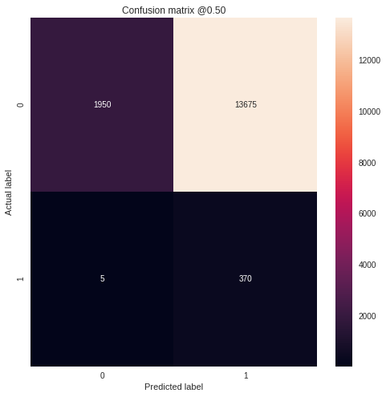

```python
plot_cm(y_test, predictions)
```

```python
if (notifyStatus): status_notify("Phase 5 Finalize Model and Make Predictions completed! "+datetime.now().strftime('%a %B %d, %Y %I:%M:%S %p'))
```

```python
print ('Total time for the script:',(datetime.now() - startTimeScript))
```

```
Total time for the script: 1:40:43.476260
```